# seqcombo for visualizing genetic reassortment

Guangchuang Yu  
School of Basic Medical Sciences, Southern Medical University

2026-08-29

Reassortment is an important strategy for influenza A viruses to introduce a HA subtype that is new to human populations, which creates the possibilities of pandemic.

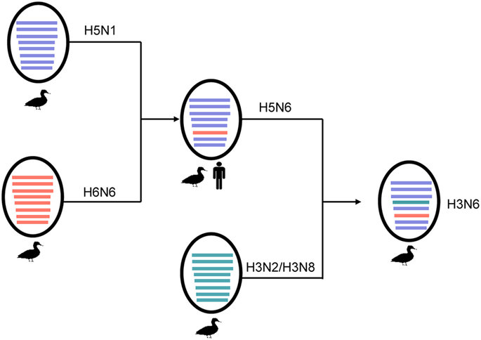

A diagram showed above (Figure 2 of `doi:10.1038/srep25549`) is widely used to illustrate the reassortment events. While such diagrams are mostly manually draw and edit without software tool to automatically generate. Here, I implemented the `hybrid_plot` function for producing publication quality figure of reassortment events.

# Recommended workflow

For most new projects, the recommended entry point is a table-based workflow:

1. Prepare a long-format virus-segment table.
2. Build `virus_info` with `build_virus_info_from_long()`.
3. Build `flow_info` with `build_flow_info_from_long()` when reassortment edges also come from tables.
4. Wrap both objects with `as_seqcombo_data()`.
5. Start with `autoplot()` and only switch to `hybrid_plot()` when you need fine-grained control.

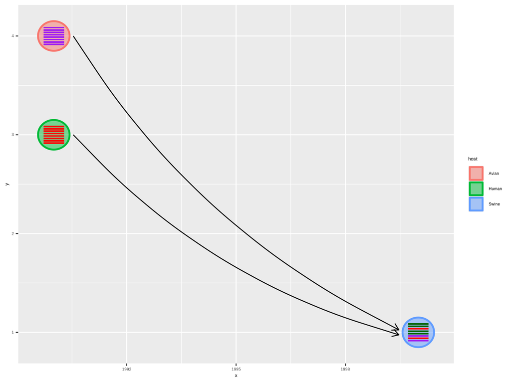

```r
workflow_segments <- data.frame(
    id = rep(c("avian_1990", "human_1990", "swine_2000"), each = 8),
    sample_time = rep(c(1990, 1990, 2000), each = 8),
    segment = rep(c("PB2", "PB1", "PA", "HA", "NP", "NA", "M", "NS"), 3),
    color = c(
        rep("purple", 8),
        rep("red", 8),
        c("darkgreen", "darkgreen", "red", "darkgreen",
          "darkgreen", "purple", "red", "purple")
    ),
    host = rep(c("Avian", "Human", "Swine"), each = 8),
    stringsAsFactors = FALSE
)

workflow_flow <- data.frame(
    from = c("avian_1990", "human_1990"),
    to = c("swine_2000", "swine_2000"),
    segment = c("HA", "NA"),
    stringsAsFactors = FALSE
)

workflow_virus <- build_virus_info_from_long(
    workflow_segments,
    x = "sample_time",
    keep = "host"
)
workflow_flow <- build_flow_info_from_long(
    workflow_flow,
    segment = "segment"
)
workflow_virus <- layout_timeline(
    workflow_virus,
    workflow_flow,
    time_col = "x"
)

workflow_data <- as_seqcombo_data(workflow_virus, workflow_flow)
autoplot(workflow_data, v_color = ~host, v_fill = ~host, link_style = "curve")
```

# Basic usage of hybrid_plot()

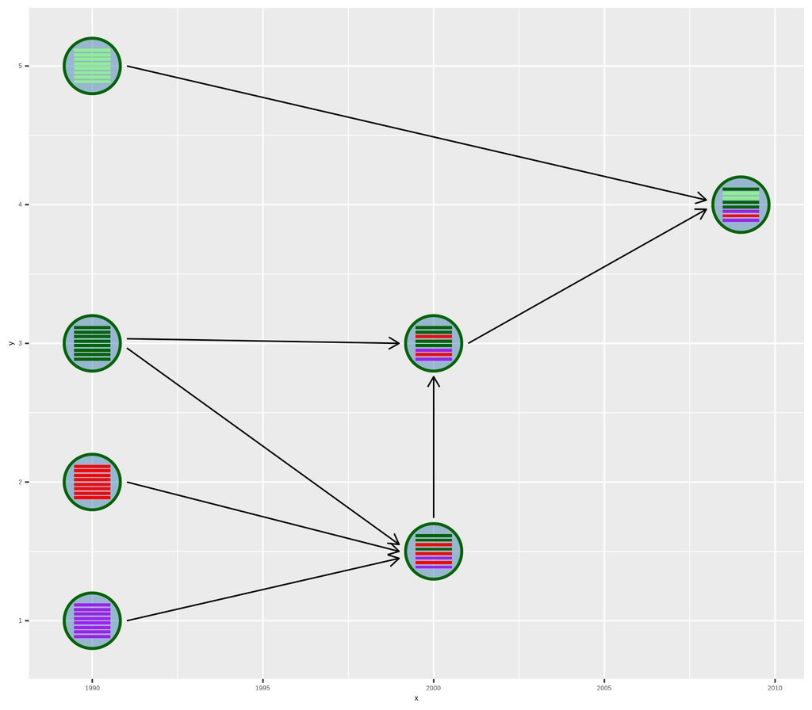

```r
n <- 8

virus_info <- build_virus_info(
    id = 1:7,
    x = c(rep(1990, 4), rep(2000, 2), 2009),
    y = c(1,2,3,5, 1.5, 3, 4),
    segment_color = list(
        rep('purple', n),
        rep('red', n),
        rep('darkgreen', n),
        rep('lightgreen', n),
        c('darkgreen', 'darkgreen', 'red', 'darkgreen', 'red', 'purple', 'red', 'purple'),
        c('darkgreen', 'darkgreen', 'red', 'darkgreen', 'darkgreen', 'purple', 'red', 'purple'),
        c('darkgreen', 'lightgreen', 'lightgreen', 'darkgreen', 'darkgreen', 'purple', 'red', 'purple'))
)

flow_info <- build_flow_info(from = c(1,2,3,3,4,5,6),
                             to = c(5,5,5,6,7,6,7))
hybrid_plot(virus_info, flow_info)
```

The `hybrid_plot` requires two tibble data frame of virus information and genetic flow information.

Users need to provide `x` and `y` positions to plot the virus, this make sense for geographically and temporally information are usually available in such phylodynamic study and can be employed to set `x` or `y` to provide more information and help interpretation of the reassortment events.

# Customizing the appearance

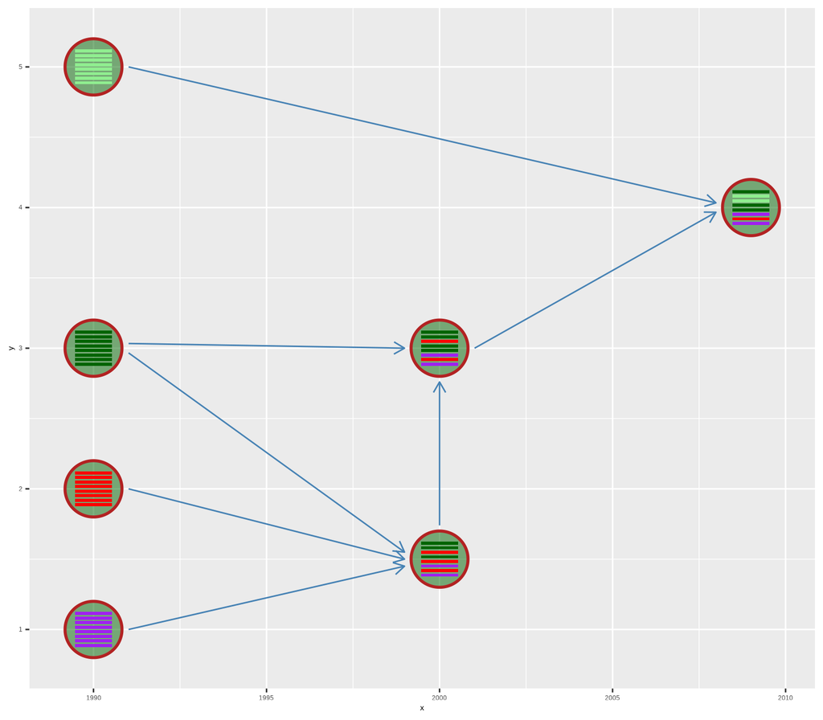

```r
hybrid_plot(virus_info, flow_info, v_color='firebrick', v_fill='darkgreen', l_color='steelblue')
```

We usually have more information to present, for example host information and HA subtype *etc.* and these information can be used to color the virus either by `v_color` or `v_fill`

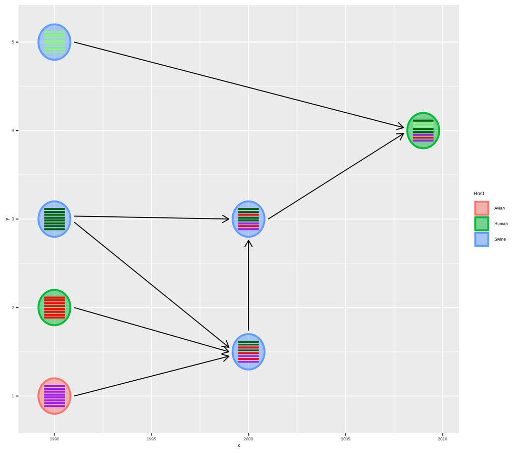

```r
virus_info$Host = c("Avian", "Human", rep("Swine", 4), "Human")
hybrid_plot(virus_info, flow_info, v_color=~Host, v_fill=~Host)
```

The relative virus size can also be specify if a `virus_size` column is available in the input `virus_info` data.

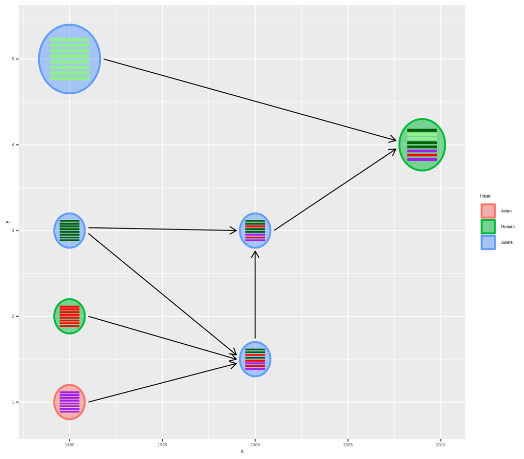

```r
virus_info$virus_size <- c(rep(1, 3), 2, 1, 1, 1.5)
hybrid_plot(virus_info, flow_info, v_color=~Host, v_fill=~Host)
```

If `label` and `label_position` coloumns are available, the virus labels (virus name or other information) will be added automatically.

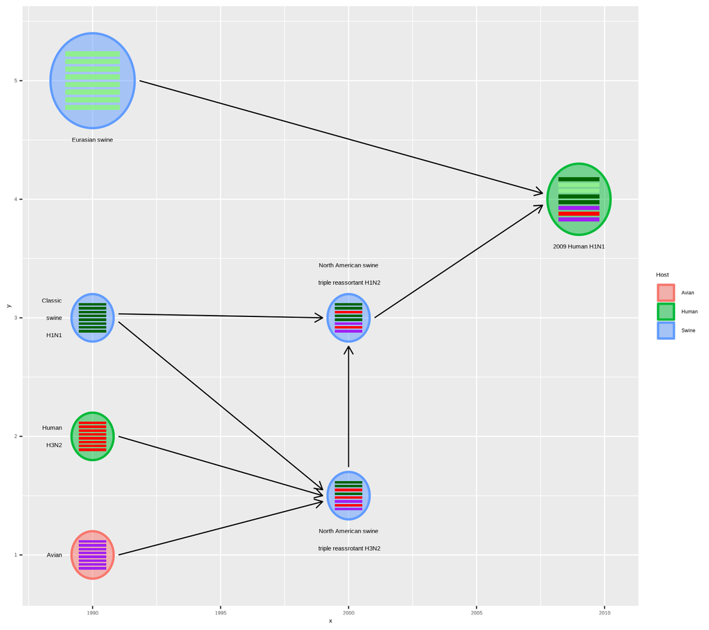

```r
virus_info$label <- c("Avian", "Human\nH3N2", "Classic\nswine\nH1N1", "Eurasian swine",
                      "North American swine\n triple reassrotant H3N2",
                      "North American swine\n triple reassortant H1N2", "2009 Human H1N1")
virus_info$label_position <- c('left', 'left', 'left', 'below', 'below', 'upper', 'below')
hybrid_plot(virus_info, flow_info, v_color=~Host, v_fill=~Host)
```

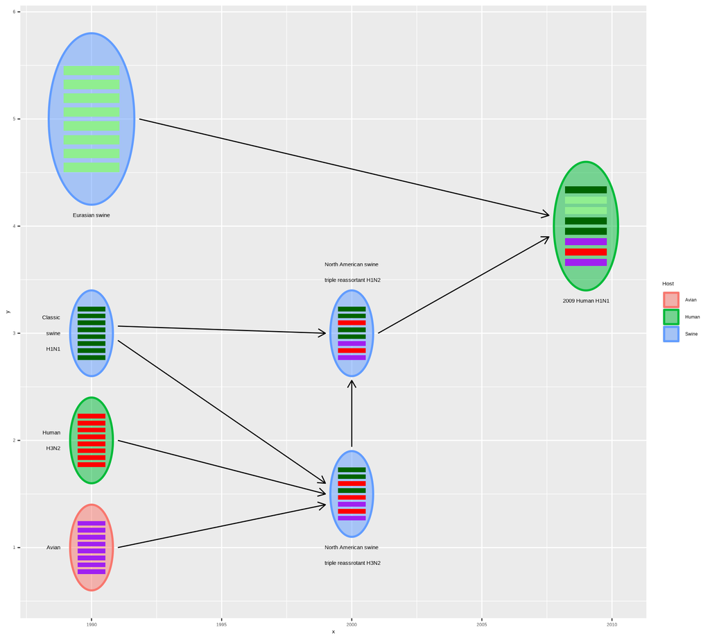

```r
hybrid_plot(virus_info, flow_info, v_color=~Host, v_fill=~Host, asp=2)
```

The output of `hybrid_plot` is a `ggplot` object and users can use `ggplot2` to modify the details.

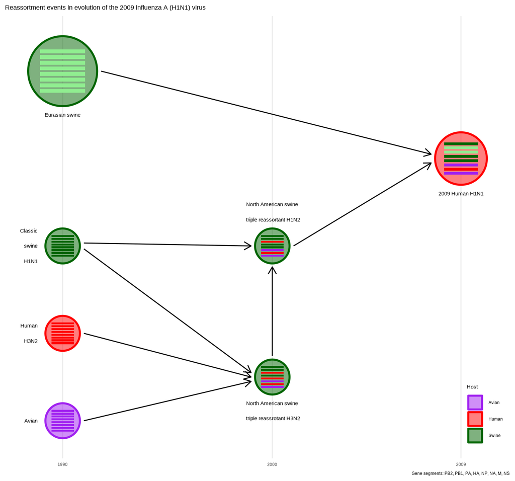

```r
title <- "Reassortment events in evolution of the 2009 influenza A (H1N1) virus"
caption <- build_segment_caption(c("PB2", "PB1", "PA", "HA", "NP", "NA", "M", "NS"))
color <- c(Avian="purple", Human="red", Swine="darkgreen")

hybrid_plot(virus_info, flow_info, v_color=~Host, v_fill=~Host) +
    labs(caption=caption, title=title) +
    scale_color_manual(values=color) + scale_fill_manual(values=color) +
    scale_x_continuous(breaks=c(1990, 2000, 2009)) +
    xlab(NULL) + ylab(NULL) + theme_minimal() +
    theme(axis.line.y = element_blank(),
          axis.text.y = element_blank(),
          axis.ticks.y = element_blank(),
          panel.grid.minor=element_blank(),
          panel.grid.major.y=element_blank(),
          legend.position = c(.95, .1)
          )
```

When coloring viruses by their host of origin, the manual scales above can be replaced by the built-in host presets from `scale_seqcombo_host()`:

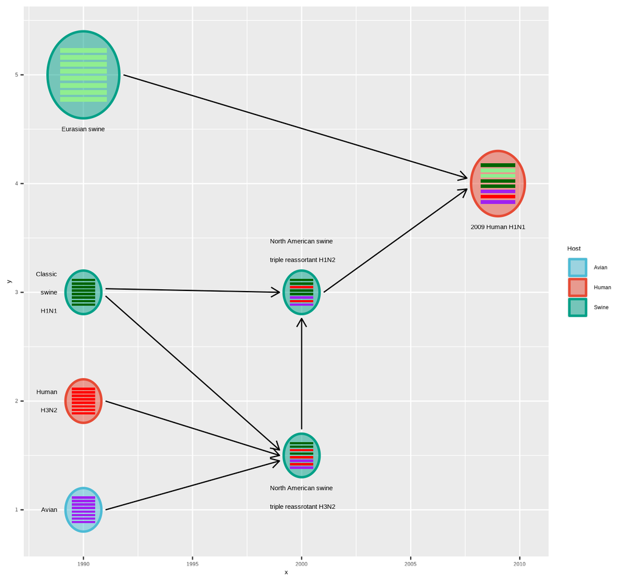

```r
hybrid_plot(virus_info, flow_info, v_color=~Host, v_fill=~Host) +
    scale_seqcombo_host()
```

Top-down or bottom-up style is also supported.

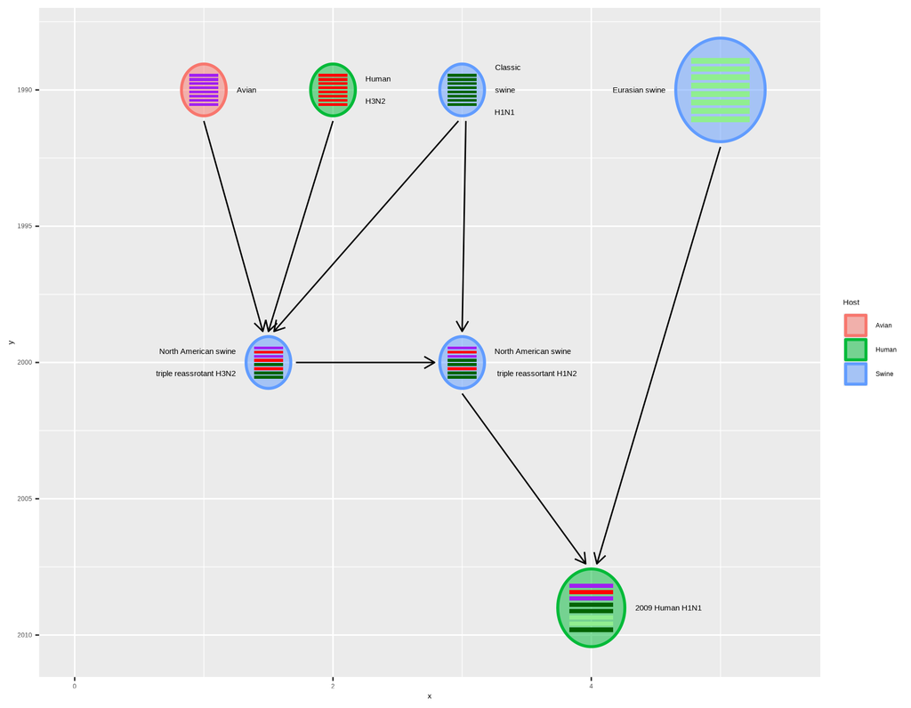

```r
x <- virus_info$x
virus_info$x <- virus_info$y
virus_info$y <- x
virus_info$label_position <- c(rep("right", 3), "left", "left", "right", "right")
hybrid_plot(virus_info, flow_info, v_color=~Host, v_fill=~Host) +
    scale_y_reverse() + scale_x_continuous(limits=c(0, 5.5))
```

When your x-axis already encodes time, you can preserve it and only arrange the y positions automatically. Viruses sharing the same time point (here 1990 and 2000) are spread into evenly spaced slots instead of stacking on top of each other:

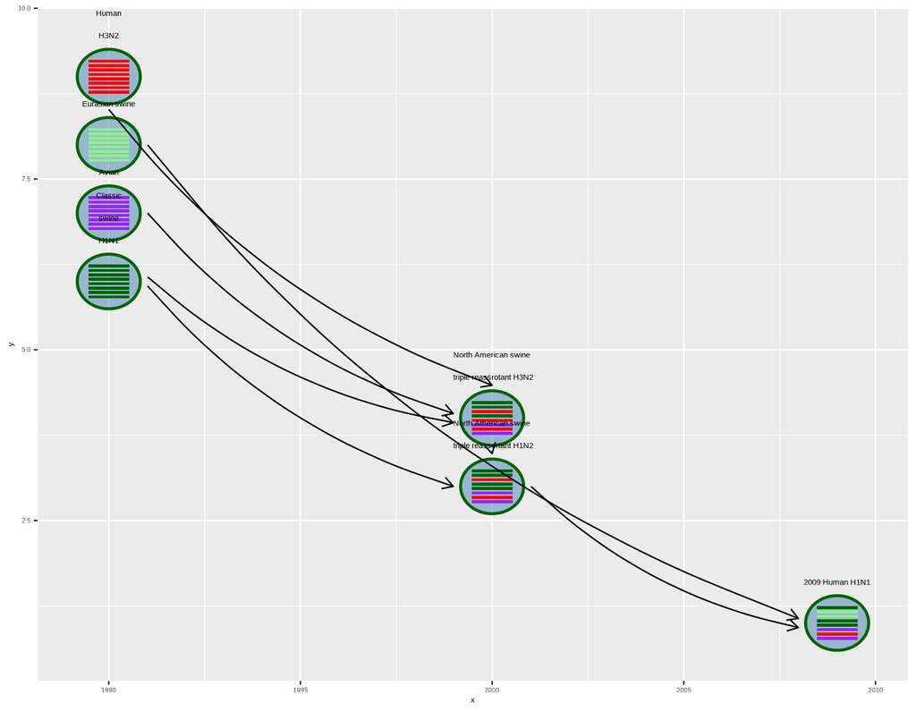

```r
virus_time <- build_virus_info(
    id = 1:7,
    x = c(rep(1990, 4), rep(2000, 2), 2009),
    segment_color = virus_info$segment_color,
    label = virus_info$label,
    label_position = rep("upper", 7)
)
virus_time <- set_layout(virus_time, flow_info, preserve_x = TRUE, spread = TRUE)
hybrid_plot(virus_time, flow_info, link_style = "curve")
```

# Building inputs from tables

For workflows that start from long-format segment records, you can build `virus_info` directly from a virus-segment table:

```r
segment_df <- data.frame(
    id = rep(c("avian", "human"), each = 8),
    segment = rep(c("PB2", "PB1", "PA", "HA", "NP", "NA", "M", "NS"), 2),
    color = c(rep("purple", 8), rep("red", 8)),
    x = rep(c(1990, 2009), each = 8),
    y = rep(c(1, 2), each = 8),
    host = rep(c("Avian", "Human"), each = 8)
)

build_virus_info_from_long(
    segment_df,
    x = "x",
    y = "y",
    keep = "host"
)
```

```
         id    x y segment_color virus_size segment_name  host
avian avian 1990 1  purple, ....          1 PB2, PB1.... Avian
human human 2009 2  red, red....          1 PB2, PB1.... Human
```

You can construct `flow_info` from long-format reassortment records as well:

```r
flow_long <- data.frame(
    from = c(1, 1, 2, 3, 3, 4),
    to = c(5, 5, 5, 6, 7, 7),
    segment = c("PB2", "HA", "NA", "PB1", "NP", "M"),
    support = c(1, 1, 2, 1, 1, 1)
)

build_flow_info_from_long(
    flow_long,
    segment = "segment",
    weight = "support"
)
```

```
  from to segment_name weight
1    1  5      PB2, HA      2
2    2  5           NA      2
3    3  6          PB1      1
4    3  7           NP      1
5    4  7            M      1
```

# Plotting time-course reassortment data

In a typical reassortment study you know **when** each virus was sampled, but you rarely know where it should sit on the canvas. This section walks through the full path from two plain tables (one row per virus-segment record, one row per reassortment flow) to a publication-ready figure with time on the x-axis. If you only want a quick look, `example_seqcombo_data("timeline")` returns ready-to-plot demo data.

## Step 1: prepare long-format tables

The first table stores segment records. Each row is one *virus-segment* combination:

```r
tl_segments <- data.frame(
    id = rep(c("avian_1990", "human_1990", "swine_2000", "human_2009"), each = 8),
    sample_time = rep(c(1990, 1990, 2000, 2009), each = 8),
    segment = rep(c("PB2", "PB1", "PA", "HA", "NP", "NA", "M", "NS"), 4),
    color = c(
        rep("purple", 8),
        rep("red", 8),
        c("darkgreen", "darkgreen", "red", "darkgreen",
          "darkgreen", "purple", "red", "purple"),
        c("darkgreen", "lightgreen", "lightgreen", "darkgreen",
          "darkgreen", "purple", "red", "purple")
    ),
    host = rep(c("Avian", "Human", "Swine", "Human"), each = 8),
    stringsAsFactors = FALSE
)
head(tl_segments)
```

```
          id sample_time segment  color  host
1 avian_1990        1990     PB2 purple Avian
2 avian_1990        1990     PB1 purple Avian
3 avian_1990        1990      PA purple Avian
4 avian_1990        1990      HA purple Avian
5 avian_1990        1990      NP purple Avian
6 avian_1990        1990      NA purple Avian
```

The second table stores reassortment flows. `from` and `to` refer to virus ids; the optional `segment` column records which segments were donated:

```r
tl_flows <- data.frame(
    from = c("avian_1990", "human_1990", "swine_2000"),
    to = c("swine_2000", "swine_2000", "human_2009"),
    segment = c("HA", "NA", "PB1"),
    stringsAsFactors = FALSE
)
```

## Step 2: build `virus_info` and `flow_info`

At this stage there is no `y` column yet — only sampling time, which we hand to the `x` argument as a column name:

```r
tl_virus <- build_virus_info_from_long(tl_segments, x = "sample_time",
                                       keep = "host")

tl_flow <- build_flow_info_from_long(tl_flows, segment = "segment")

tl_virus[, c("id", "x")]
```

```
                   id    x
avian_1990 avian_1990 1990
human_1990 human_1990 1990
human_2009 human_2009 2009
swine_2000 swine_2000 2000
```

## Step 3: arrange the timeline

`layout_timeline()` keeps the time axis untouched (`time_col = "x"`) and fills in sensible y positions based on the flow network:

```r
tl_virus <- layout_timeline(tl_virus, tl_flow, time_col = "x")
```

## Step 4: plot

Wrap everything into a `seqcombo_data` object and call `autoplot()`:

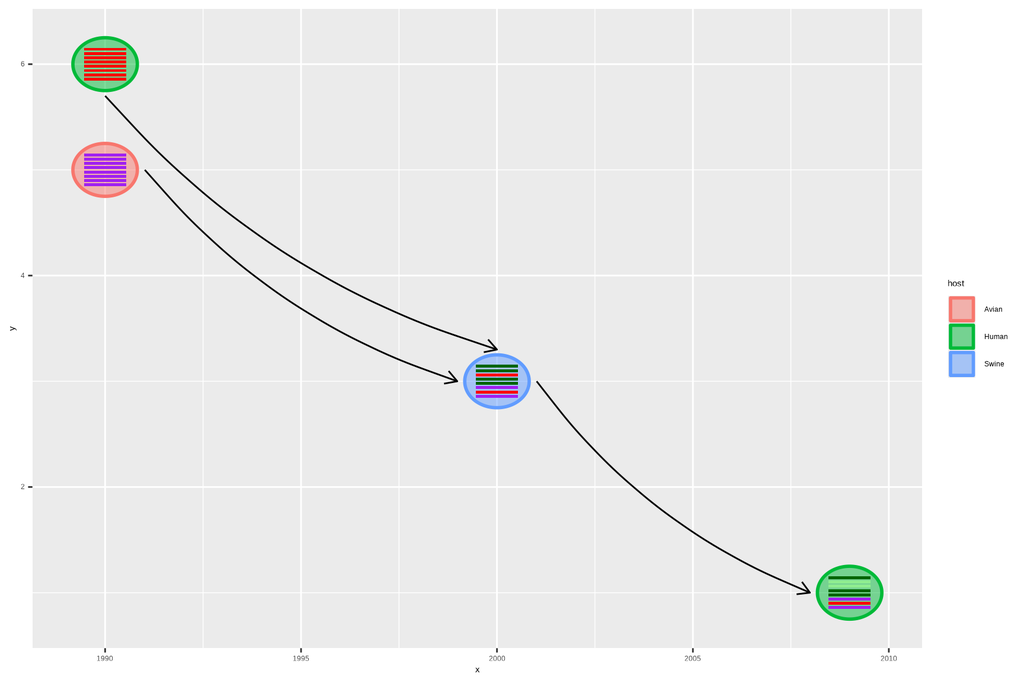

```r
tl_data <- as_seqcombo_data(tl_virus, tl_flow)

autoplot(tl_data, v_color = ~host, v_fill = ~host, link_style = "curve")
```

That is the complete workflow: two tables in, one figure out.

## Polishing the figure

Host colors work better with an explicit palette. The built-in `scale_seqcombo_host()` wires both `colour` and `fill` aesthetics to a curated host palette, and `build_segment_caption()` turns segment names into a readable caption:

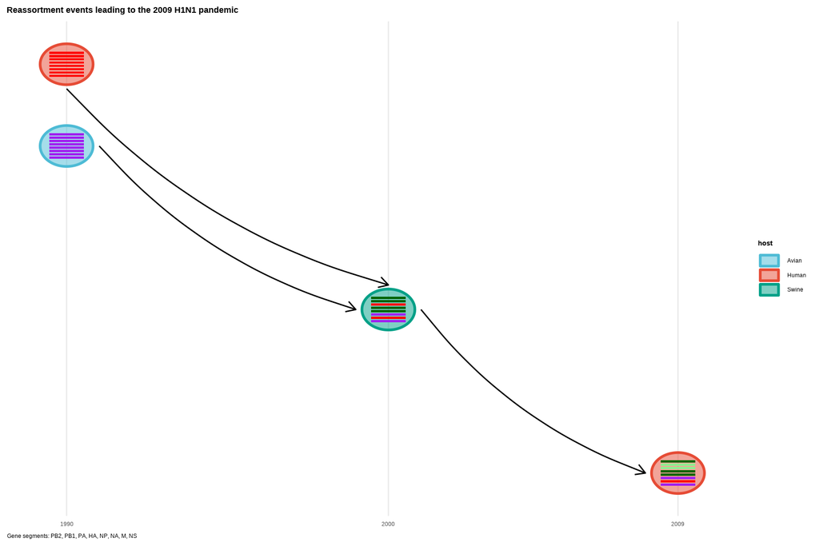

```r
autoplot(tl_data, v_color = ~host, v_fill = ~host, link_style = "curve") +
    scale_seqcombo_host() +
    labs(title = "Reassortment events leading to the 2009 H1N1 pandemic",
         caption = build_segment_caption(c("PB2", "PB1", "PA", "HA",
                                           "NP", "NA", "M", "NS"))) +
    scale_x_continuous(breaks = c(1990, 2000, 2009)) +
    theme_seqcombo_pub()
```

Labels can be added by attaching `label` and `label_position` columns before building the plot:

```r
tl_labeled <- tl_data$virus_info
tl_labeled$label <- c("Avian H1N1", "Human seasonal H3N2",
                      "Triple-reassortant swine H3N2", "2009 pandemic H1N1")
tl_labeled$label_position <- c("left", "left", "below", "below")

tl_data_labeled <- as_seqcombo_data(tl_labeled, tl_data$flow_info)
```

[figure not shown]

```r
autoplot(tl_data_labeled, v_color = ~host, v_fill = ~host,
         link_style = "curve") + theme_seqcombo_pub()
```

For dense timelines, elbow links often read more clearly than curves:

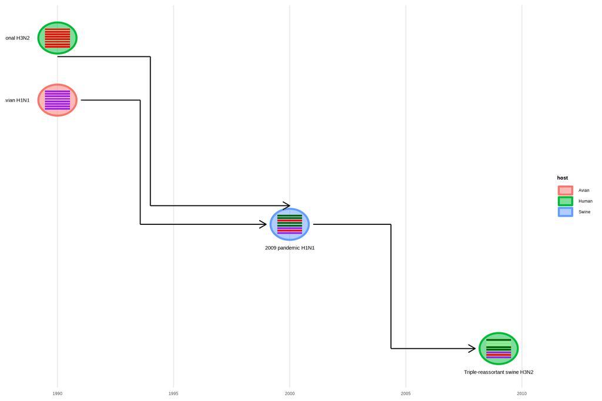

```r
autoplot(tl_data_labeled, v_color = ~host, v_fill = ~host,
         link_style = "elbow", link_elbow_position = 0.4) +
    theme_seqcombo_pub()
```

If both input tables carry a grouping variable, `facet_by` splits the history into panels — useful when several lineages co-circulate:

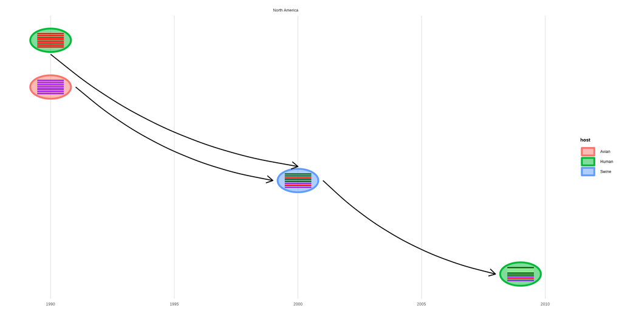

```r
tl_info_facet <- tl_data$virus_info
tl_info_facet$Lineage <- c("North America", "North America",
                           "North America", "North America")
tl_flow_facet <- tl_data$flow_info
tl_flow_facet$Lineage <- tl_info_facet$Lineage[match(tl_flow_facet$to,
                                                     tl_info_facet$id)]

autoplot(as_seqcombo_data(tl_info_facet, tl_flow_facet),
         v_color = ~host, v_fill = ~host,
         link_style = "curve", facet_by = "Lineage") +
    theme_seqcombo_pub()
```

## Notes

- Sampling times do not need to be years; dates (e.g., `"2024-03-01"`) or any numeric encoding works, since the values are passed through to ggplot2.
- If you prefer manual control at every step, replace `as_seqcombo_data()` + `autoplot()` with direct calls to `hybrid_plot()` — as shown in the sections above.

# Segment labels inside the glyphs

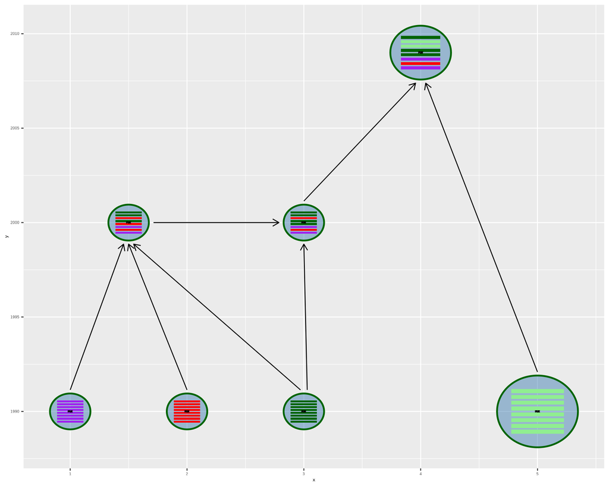

```r
segment_table <- do.call(rbind, lapply(seq_len(nrow(virus_info)), function(i) {
    data.frame(
        id = virus_info$id[i],
        segment = c("PB2", "PB1", "PA", "HA", "NP", "NA", "M", "NS"),
        color = virus_info$segment_color[[i]],
        x = virus_info$x[i],
        y = virus_info$y[i],
        stringsAsFactors = FALSE
    )
}))

virus_labeled <- build_virus_info_from_long(
    segment_table,
    x = "x",
    y = "y",
    segment_order = c("PB2", "PB1", "PA", "HA", "NP", "NA", "M", "NS")
)
virus_labeled$virus_size <- virus_info$virus_size

hybrid_plot(
    virus_labeled,
    flow_info,
    show_segment_label = TRUE,
    segment_text_size = 2.5
)
```

If you want temporal flows to read more like a timeline, elbow links can make the transitions easier to follow:

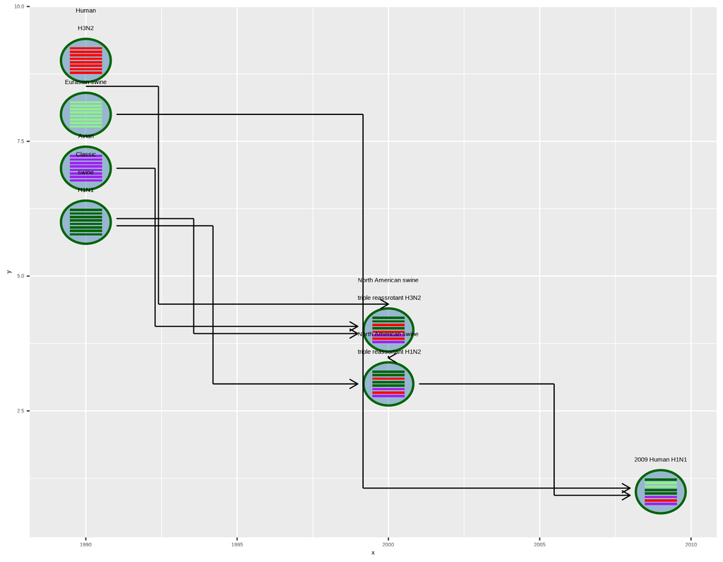

```r
hybrid_plot(
    virus_time,
    flow_info,
    link_style = "elbow",
    link_elbow_position = 0.4
)
```

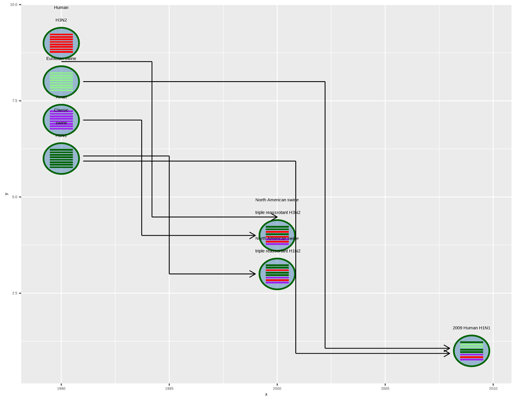

```r
flow_strength <- build_flow_info_from_long(
    flow_long,
    segment = "segment",
    weight = "support"
)
flow_strength$alpha <- c(0.5, 0.7, 0.9, 0.7, 0.8)

hybrid_plot(
    virus_time,
    flow_strength,
    link_style = "elbow",
    l_width = ~weight,
    l_alpha = ~alpha
)
```

The `layout_timeline()` helper keeps the temporal axis fixed while arranging the other axis automatically:

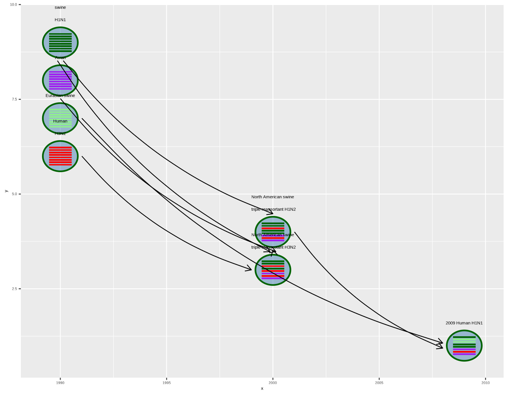

```r
virus_timeline <- layout_timeline(virus_time, flow_info, time_col = "x")
hybrid_plot(virus_timeline, flow_info, link_style = "curve")
```

When `virus_info` carries a grouping variable, you can facet reassortment histories by group. Flows that cross facets are drawn in each panel, so transitions between lineages remain visible:

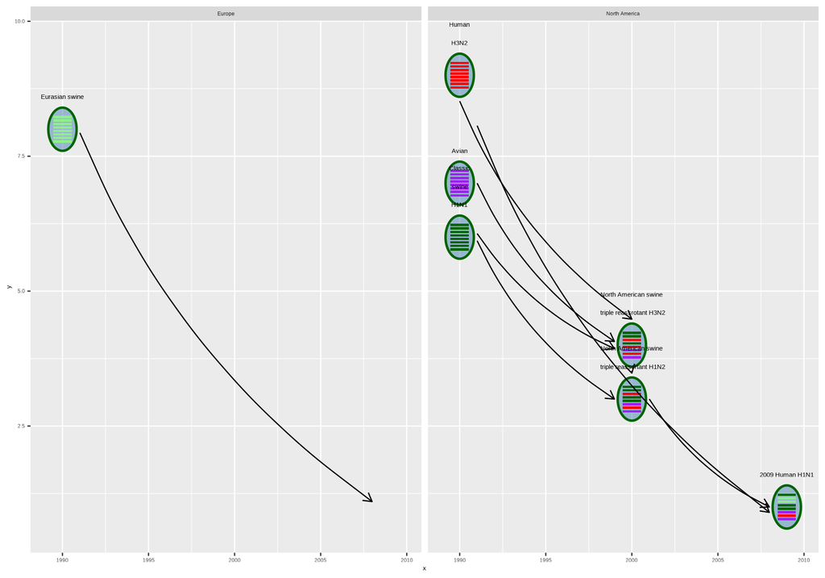

```r
virus_time$Lineage <- c("North America", "North America", "North America",
                        "Europe", "North America", "North America", "North America")

hybrid_plot(
    virus_time,
    flow_info,
    link_style = "curve",
    facet_by = "Lineage"
)
```

For a shorter workflow, you can bundle inputs into a `seqcombo_data` object, validate them, and call `autoplot()` directly:

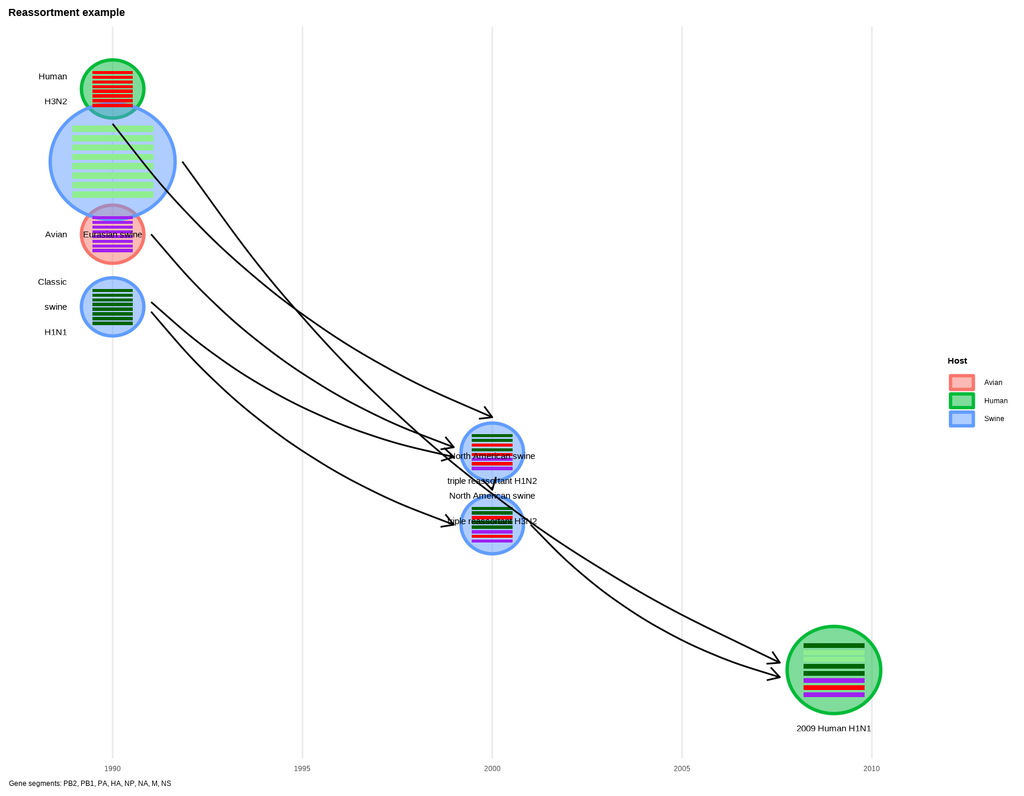

```r
demo_data <- example_seqcombo_data("timeline")
check_seqcombo_data(demo_data)

ggplot2::autoplot(
    demo_data,
    v_color = ~Host,
    v_fill = ~Host,
    link_style = "curve"
) +
    theme_seqcombo_pub() +
    ggplot2::labs(
        title = "Reassortment example",
        caption = build_segment_caption(demo_data$virus_info$segment_name)
    )
```

`example_seqcombo_data()` also ships dedicated teaching datasets. Type `"long"` starts from tidy tables (attached as `attr(demo, "long_tables")`) and walks through the recommended build-and-arrange pipeline, so you can inspect each intermediate step:

```r
long_demo <- example_seqcombo_data("long")
head(attr(long_demo, "long_tables")$flows)
```

```
                 from                  to support
1          avian_1996 swine_eurasian_2002    0.62
2          avian_1996   swine_triple_2008    0.84
3 swine_eurasian_2002   swine_triple_2008    0.58
4   swine_triple_2008  pandemic_h1n1_2009    0.91
```

[figure not shown]

```r
ggplot2::autoplot(
    long_demo,
    v_color = ~sampling_host,
    v_fill = ~sampling_host,
    l_width = ~weight,
    link_style = "curve"
) +
    scale_seqcombo_host() +
    theme_seqcombo_pub()
```

Type `"genotype"` provides parents plus reassortants without flows, handy for genotype-only charts through `geom_genotype()` or `autoplot(as_seqcombo_data(virus_info))`.

# Emoji text and automatic layouts

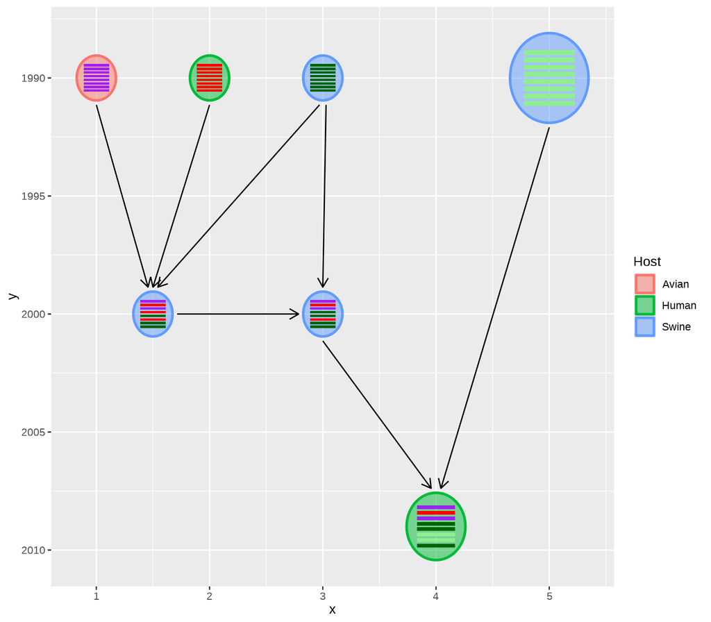

```r
hybrid_plot(virus_info, flow_info, v_color=~Host, v_fill=~Host,
              parse='emoji', t_size=8, t_color='firebrick') +
    scale_y_reverse()
```

In case you don’t have xy-coordination information, you can use `set_layout` function to auto setting the xy position using selected layout function.

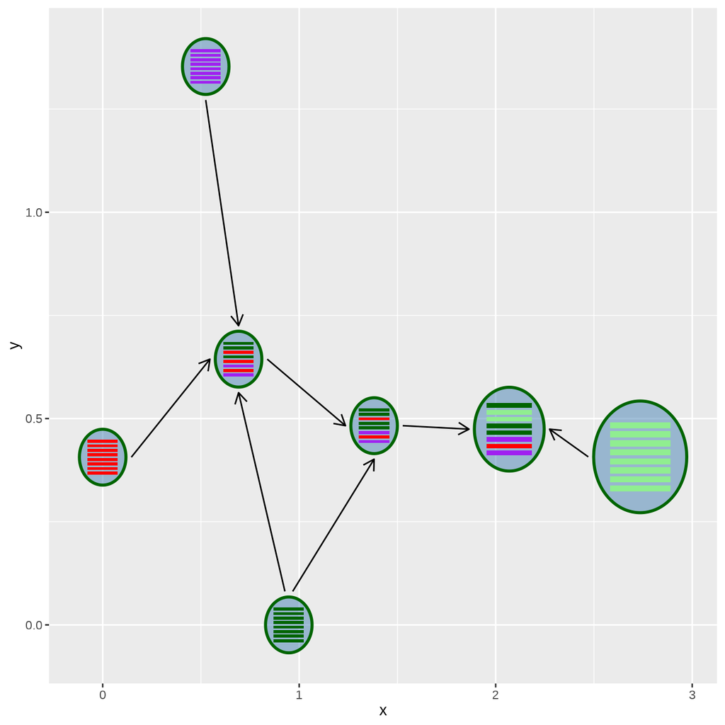

```r
virus_info <- set_layout(virus_info, flow_info, layout="layout.kamada.kawai")
hybrid_plot(virus_info, flow_info, parse='emoji', t_size=8, t_color='firebrick')
```

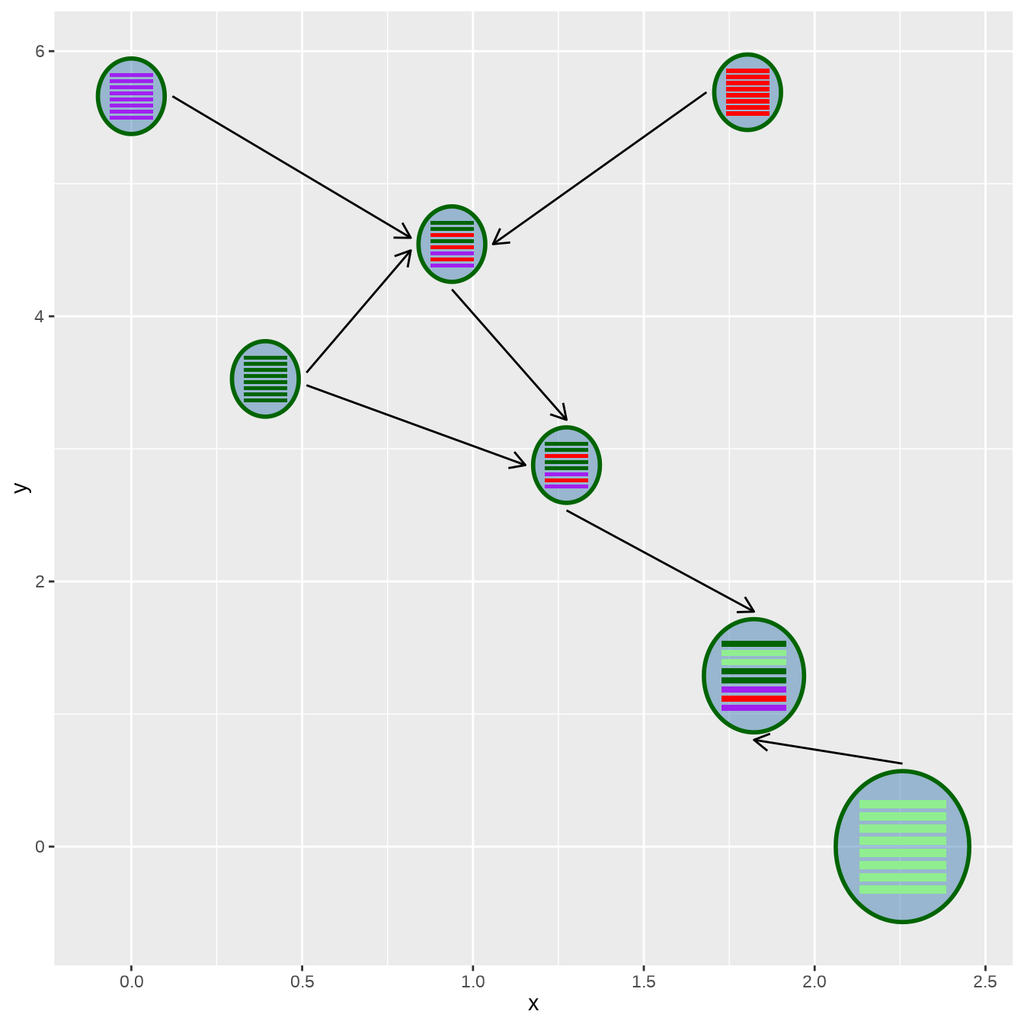

```r
virus_info <- set_layout(virus_info, flow_info, layout="layout.fruchterman.reingold")
hybrid_plot(virus_info, flow_info, parse='emoji', t_size=8, t_color='firebrick')
```